# **Advanced Data Science Pipeline Tutorial for Stroke Data Analysis and Classification**

# by Sarvesh Gadre

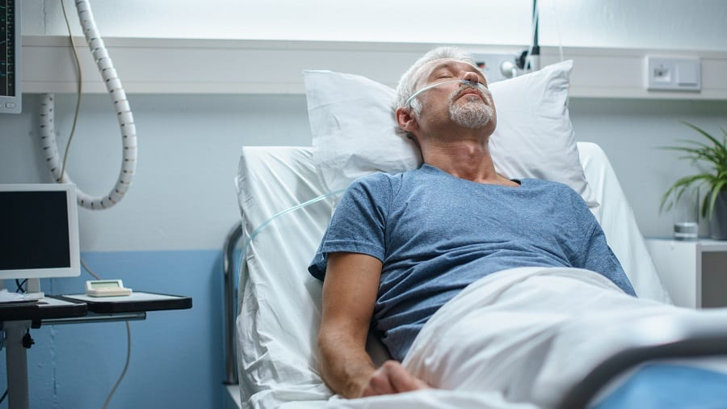

# Introduction

According to the Center for Disease Control and Prevention , a person experiences a stroke every 40 seconds. Strokes occur when the blood supply to your brain is diminished, preventing your brain from getting oxygen and vital nutrients. Strokes could be a result of countless factors that affect human health, and due to the gravity of this medical emergency, it is important that these factors be analyzed so that doctors and healthcare professionals can properly implement the solutions to effectively combat it. In this tutorial, we follow through the entire data science pipeline to make meaningful inferences about the factors related to patients experiencing strokes.

The dataset contains various attributes of patient data, including uniuque ID, gender, age, body mass index, and an binary attribute describing whether a patient was victim to a stroke. Here is the link to the original dataset below:

https://www.kaggle.com/fedesoriano/stroke-prediction-dataset

# Data Collection, Preparation, and Representation

We use the pandas dataframe to read the CSV data file into a table format. The shape function shows that there are 5110 rows (examples) and 12 columns (attributes).

The numpy library is used to run the function np.unique, which gives an overview of the possible values that each of the categorical variables takes.

Use the links below to learn more about how to use the Pandas and Numpy libraries.

Pandas User Guide: https://pandas.pydata.org/docs/user_guide/index.html#user-guide

Numpy User Guide: https://numpy.org/doc/stable/user/

We will be using both libraries to do various operations on our data, throughout this tutorial.

```python
import pandas as pd
import numpy as np

data = pd.read_csv('healthcare-dataset-stroke-data.csv')
print(data.head())

#Print the label of the column attributes
print(data.columns)

#Print the shape of the table in (x, y) format.
print(data.shape)

#For each of the multi-level categorical variables, list the unique possible types.
print("Types of Residence:")
print(np.unique(data['Residence_type']))

print("Smoking Status possible values:")
print(np.unique(data['smoking_status']))

print("Work Types:")
print(np.unique(data['work_type']))

print("Marriage Status")
print(np.unique(data['ever_married']))
```

```
      id  gender   age  ...   bmi   smoking_status stroke
0   9046    Male  67.0  ...  36.6  formerly smoked      1
1  51676  Female  61.0  ...   NaN     never smoked      1
2  31112    Male  80.0  ...  32.5     never smoked      1
3  60182  Female  49.0  ...  34.4           smokes      1
4   1665  Female  79.0  ...  24.0     never smoked      1

[5 rows x 12 columns]
Index(['id', 'gender', 'age', 'hypertension', 'heart_disease', 'ever_married',
       'work_type', 'Residence_type', 'avg_glucose_level', 'bmi',
       'smoking_status', 'stroke'],
      dtype='object')
(5110, 12)
Types of Residence:
['Rural' 'Urban']
Smoking Status possible values:
['Unknown' 'formerly smoked' 'never smoked' 'smokes']
Work Types:
['Govt_job' 'Never_worked' 'Private' 'Self-employed' 'children']
Marriage Status
['No' 'Yes']
```

In this section, we transform the way data is currently represented to make it more suitable for analysis.

We first drop the columns that are irrelevant to analysis. This includes the id (first) column. We also drop rows with missing values, which are represented by NaN, meaning not a number. There are other types of missing values, and different ways to handle them. You can find a thorough overview of them here: https://pandas.pydata.org/pandas-docs/stable/user_guide/missing_data.html#:~:text=Values%20considered%20%E2%80%9Cmissing%E2%80%9D,-As%20data%20comes&text=While%20NaN%20is%20the%20default,%2C%20boolean%2C%20and%20general%20object.

In case the smoking status has a significant effect on other variables in the data, we also drop the rows where the smoking status of the patient is unknown.

```python
#Drop the ID column from the dataframe.
data = data.drop(columns=['id'])
#Drop all the columns with missing values for BMI.
data = data.dropna()

#Change the data table to include only the entries where the smoking status is not unknown.
data = data[data['smoking_status'] != 'Unknown']

data
```

|  | gender | age | hypertension | heart_disease | ever_married | work_type | Residence_type | avg_glucose_level | bmi | smoking_status | stroke |
| --- | --- | --- | --- | --- | --- | --- | --- | --- | --- | --- | --- |
| 0 | Male | 67.0 | 0 | 1 | Yes | Private | Urban | 228.69 | 36.6 | formerly smoked | 1 |
| 2 | Male | 80.0 | 0 | 1 | Yes | Private | Rural | 105.92 | 32.5 | never smoked | 1 |
| 3 | Female | 49.0 | 0 | 0 | Yes | Private | Urban | 171.23 | 34.4 | smokes | 1 |
| 4 | Female | 79.0 | 1 | 0 | Yes | Self-employed | Rural | 174.12 | 24.0 | never smoked | 1 |
| 5 | Male | 81.0 | 0 | 0 | Yes | Private | Urban | 186.21 | 29.0 | formerly smoked | 1 |
| ... | ... | ... | ... | ... | ... | ... | ... | ... | ... | ... | ... |
| 5100 | Male | 82.0 | 1 | 0 | Yes | Self-employed | Rural | 71.97 | 28.3 | never smoked | 0 |
| 5102 | Female | 57.0 | 0 | 0 | Yes | Private | Rural | 77.93 | 21.7 | never smoked | 0 |
| 5106 | Female | 81.0 | 0 | 0 | Yes | Self-employed | Urban | 125.20 | 40.0 | never smoked | 0 |
| 5107 | Female | 35.0 | 0 | 0 | Yes | Self-employed | Rural | 82.99 | 30.6 | never smoked | 0 |
| 5108 | Male | 51.0 | 0 | 0 | Yes | Private | Rural | 166.29 | 25.6 | formerly smoked | 0 |

3426 rows × 11 columns

Finally, we assign binary numbers (0 or 1) to values representing gender, ever_married, and Residence_type:

Gender: Female = 0, Male = 1

- Gender: Female = 0, Male = 1
- ever_married: No = 0, Yes = 1
- Residence Type: Rural = 0, Urban = 1

Turning categorical variables into numerical variables enables them to be used for analysis in machine learning algorithms.

Note that for categorical variables with more than k levels, where k > 2, we cannot simply map them to values 0, 1, 2, ..., k. We must use alternate strategies such as one-hot encoding. This will be explained later on in this tutorial.

```python
#Change the value of the following columns Residence_type, ever_married, and gender
#to binary values, using list comprehensions:
data['gender'] = data['gender'].map(lambda x: 0 if x == 'Female' else 1)
data['ever_married'] = data['ever_married'].map(lambda x: 0 if x == 'No' else 1)
data['Residence_type'] = data['Residence_type'].map(lambda x: 0 if x == 'Rural' else 1)
```

In our polished data, there are 8 categorical variables, and 3 of them (hypertension, heart_disease, and stroke) have already been converted into numerical, binary values. For the other 5 variables, we have two main techniques in order to convert the data into numerical values: enumeration or one-hot encoding.

For the categorical variables with only 2 possible levels (yes or no, male or female, etc), it is logical to simply use enumeration and map one outcome to 0, and the other outcome to 1.

However, enumeration is not logical for categorical variables with more than 2 levels, unless the values are structured in a very specific way such that makes the numerical comparison sensible - this is extremeley unlikely. For our current example, it is far more reasonable one-hot encoding, which involves the use of 1 dummy variable for each level of the categorical variable.

You can learn more about dummy variables and their implementation here: https://towardsdatascience.com/one-hot-encoding-multicollinearity-and-the-dummy-variable-trap-b5840be3c41a

A great insight that can be drawn from the data is the degree to which the variables correlate with each other. We can use a correlation matrix where each element is the r-value, or the correlation coefficient, for the corresponding variables.

A positive r-value indicates a positive correlation, whereas a negative r-value indicates a negative correlation. An r-value close to (+/-) 1 shows a strong relationship between 2 variables, and an r-value closer to 0 shows a weak relationship.

You can find out more about correlation analysis through this webpage: https://www.surveysystem.com/correlation.htm#:~:text=The%20main%20result%20of%20a,no%20relationship%20between%20the%20variables.

```python
#Print the correlation matrix of the various variables included in the data.
data.corr()
```

|  | gender | age | hypertension | heart_disease | ever_married | Residence_type | avg_glucose_level | bmi | stroke |
| --- | --- | --- | --- | --- | --- | --- | --- | --- | --- |
| gender | 1.000000 | 0.044123 | 0.037709 | 0.101718 | 0.017418 | -0.013778 | 0.070415 | 0.013884 | 0.012324 |
| age | 0.044123 | 1.000000 | 0.267098 | 0.260108 | 0.523289 | 0.015824 | 0.233649 | 0.079666 | 0.242495 |
| hypertension | 0.037709 | 0.267098 | 1.000000 | 0.111707 | 0.116851 | -0.003264 | 0.168673 | 0.132635 | 0.143647 |
| heart_disease | 0.101718 | 0.260108 | 0.111707 | 1.000000 | 0.076684 | 0.010011 | 0.143085 | 0.001288 | 0.138553 |
| ever_married | 0.017418 | 0.523289 | 0.116851 | 0.076684 | 1.000000 | 0.009857 | 0.118600 | 0.155502 | 0.071691 |
| Residence_type | -0.013778 | 0.015824 | -0.003264 | 0.010011 | 0.009857 | 1.000000 | -0.012047 | -0.008455 | 0.006068 |
| avg_glucose_level | 0.070415 | 0.233649 | 0.168673 | 0.143085 | 0.118600 | -0.012047 | 1.000000 | 0.156404 | 0.140453 |
| bmi | 0.013884 | 0.079666 | 0.132635 | 0.001288 | 0.155502 | -0.008455 | 0.156404 | 1.000000 | 0.011673 |
| stroke | 0.012324 | 0.242495 | 0.143647 | 0.138553 | 0.071691 | 0.006068 | 0.140453 | 0.011673 | 1.000000 |

From the correlation matrix, we can see that most of the variables have a very weak correlation with each other since their values are close to 0, making them optimal for analysis. This is because when predicting the value of the target variable (stroke), association between the predictors (all the other variables) could cause wildly incorrect results. Therefore it is important to make sure that none of the predictor variables correlate with each other.

However, age does have a somewhat significant association with marriage status (indicated by 'ever_married'). This makes sense because older adults are much more likely to be married or have been married than younger adults. We must explore this relationship visually and analytically in order to get a better understanding of how these two variables relate.

# Hypothesis Testing

In this section, we do a linear regression t-test between the variables age and Marriage status.

Null Hypothesis: In the regression equation between age and marriage status, the slope is 0 (no relationship between the variables).

Alternate Hypothesis: In the regression equation between age and marriage status, the slope is not 0 (there is a relationship between the variables).

We use the matplotlib.pyplot module in order to create violinplots for the data. The matplotlib module can be used to show various graphical displays like scatterplots, bar graphs, violinplots, and more.

You can read the matplotlib documentation here: https://matplotlib.org/stable/api/_as_gen/matplotlib.pyplot.html

Violinplots show the distribution of a continuous variable over a discrete, or categorical variable. In this case, we attempt to track the distribution of age (continuous variable) with marriage status (categorical variable).

```
{'bodies': [<matplotlib.collections.PolyCollection at 0x7f231f319490>,
 'cbars': <matplotlib.collections.LineCollection at 0x7f23231178d0>,
 'cmaxes': <matplotlib.collections.LineCollection at 0x7f231f29aa90>,
 'cmeans': <matplotlib.collections.LineCollection at 0x7f231f354090>,
 'cmins': <matplotlib.collections.LineCollection at 0x7f231f319710>}
```

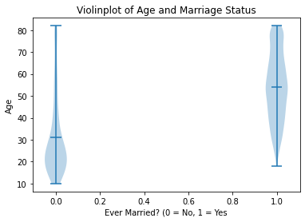

```python
import matplotlib.pyplot as plt

#Extracting the list of unique 'stroke' values from the data ([0, 1])
marriage_val_list = np.unique(data['ever_married'])
#Creating an array to store 2 numpy arrays - one for the ages of patients who
#have been married and one for the patients who have not.
age_list = []

#Setting the axis labels and title.
plt.title('Violinplot of Age and Marriage Status')
plt.xlabel("Ever Married? (0 = No, 1 = Yes")
plt.ylabel("Age")

#Create 2 temporary tables - one for patients where stroke = 0 and one for patients where stroke = 1
for val in marriage_val_list:
  temp = data[data['ever_married'] == val]
  #Convert the age column in this dataframe to a numpy array, and append it to the final list.
  ages = temp['age'].to_numpy()
  age_list.append(ages)

#Creating the violinplot, using the example shown in the instructions.
plt.violinplot(age_list, marriage_val_list, widths=.1, showmeans=True)
```

The violin plot shows that the distributions of age based on marriage status differ significantly. The mean age of the distribution of patients who have never been married ('ever_married' = 0) is approximately 31, while the mean age of the distribution of patients who have been marrieed before ('ever_married = 1) is approximately 55.

The distribution of ages seems symmetric for the patients whose marriage status is 1, but heavily right skewed for the patients whose marriage status is 0.

Let's use the statsmodels library to verify this visual result. statsmodels.formula.api contains numerous different functions for statistical analysis, exploration, and hypothesis testing. In our cases, we will be using this module to perform an ordinary linear squares regression, a technique where a regression line x and y intercept are chosen such that the square of all the residuals is minized.

You can also find out more about the statsmodels module here: https://www.statsmodels.org/stable/index.html

A residual is the difference between the predicted value and the actual value from the dataset.

You can find more about ordinary least squares regression here: https://www.xlstat.com/en/solutions/features/ordinary-least-squares-regression-ols

```python
from statsmodels.formula.api import ols
(ols("age ~ ever_married", data).fit()).summary()
```

OLS Regression Results

| Dep. Variable: | age | R-squared: | 0.274 |
| --- | --- | --- | --- |
| Model: | OLS | Adj. R-squared: | 0.274 |
| Method: | Least Squares | F-statistic: | 1291. |
| Date: | Mon, 17 May 2021 | Prob (F-statistic): | 3.25e-240 |
| Time: | 19:46:03 | Log-Likelihood: | -14373. |
| No. Observations: | 3426 | AIC: | 2.875e+04 |
| Df Residuals: | 3424 | BIC: | 2.876e+04 |
| Df Model: | 1 |  |  |
| Covariance Type: | nonrobust |  |  |

|  | coef | std err | t | P>\|t\| | [0.025 | 0.975] |
| --- | --- | --- | --- | --- | --- | --- |
| Intercept | 31.1608 | 0.559 | 55.775 | 0.000 | 30.065 | 32.256 |
| ever_married | 23.0489 | 0.641 | 35.933 | 0.000 | 21.791 | 24.307 |

| Omnibus: | 103.274 | Durbin-Watson: | 1.886 |
| --- | --- | --- | --- |
| Prob(Omnibus): | 0.000 | Jarque-Bera (JB): | 110.549 |
| Skew: | 0.430 | Prob(JB): | 9.88e-25 |
| Kurtosis: | 2.815 | Cond. No. | 3.85 |

Warnings:  
[1] Standard Errors assume that the covariance matrix of the errors is correctly specified.

In the results, "P > |t|" for the intercept and ever_married represent the probability of observing a result as extreme, or more extreme, than the one observed while performing the test.

Since the p-value of the result is approximately 0.00, we can reject the null hypothesis at a 0.01 significance level. There is sigificant evidence to suggest that the slope significantly differs from 0, and that the 2 variables are related.

We obviously cannot use both of these variables in our analysis, since they are associated with each other. We must either use an interaction term or remove one of the variables altogether. In this situation, it is much more optimal to completely remove marriage status from the analysis because the variable is very much related to the age of the patient. They are not seemingly unrelated factors that simply happen to be correlated - if so, we would have added an interaction term.

You can read about interaction terms, and implementing them here: https://www.dummies.com/programming/big-data/data-science/data-science-how-to-create-interactions-between-variables-with-python/

```python
data = data.drop(columns='ever_married')
```

# Exploratory Data Analysis

We would now like to track how each of our continuous variables (age, bmi, and glucose levels) affects whhether a patient had a stroke.

Since stroke is a categorical variable with values (0 and 1), it makes more sense to use a violinplot instead of a scatterplot or a barchart. This is because the violinplot allows you to visualize the center and spread of the data very clearly, which is especially useful when drawing differences across levels of categorical variables. A scatterplot or bar graph will not give any meaningful results when one of the variables is categorical.

This guide shares information about how to interpret the results of a violin plot: https://chartio.com/learn/charts/violin-plot-complete-guide/

```
{'bodies': [<matplotlib.collections.PolyCollection at 0x7f2305bf8050>,
 'cbars': <matplotlib.collections.LineCollection at 0x7f2305bf8990>,
 'cmaxes': <matplotlib.collections.LineCollection at 0x7f2305bf8590>,
 'cmeans': <matplotlib.collections.LineCollection at 0x7f2305beac10>,
 'cmins': <matplotlib.collections.LineCollection at 0x7f2305bf8210>}
```

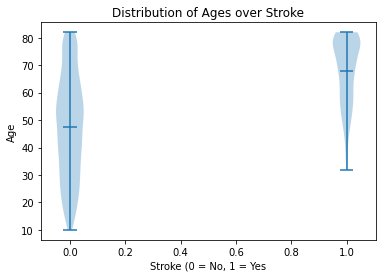

```python
import matplotlib.pyplot as plt

#Extracting the list of unique 'stroke' values from the data ([0, 1])
stroke_val_list = np.unique(data['stroke'])
#Creating an array to store 2 numpy arrays - one for the ages of patients who
#had a stroke and one for the patients who did not.
age_list = []

#Setting the axis labels and title.
plt.title('Distribution of Ages over Stroke')
plt.xlabel("Stroke (0 = No, 1 = Yes")
plt.ylabel("Age")

#Create 2 temporary tables - one for patients where stroke = 0 and one for patients where stroke = 1
for val in stroke_val_list:
  temp = data[data['stroke'] == val]
  #Convert the age column in this dataframe to a numpy array, and append it to the final list.
  ages = temp['age'].to_numpy()
  age_list.append(ages)

#Creating the violinplot, using the example shown in the instructions.
plt.violinplot(age_list, stroke_val_list, widths=.1, showmeans=True)
```

The violinplot shows that the distribution of ages for patients who had a stroke differs significantly from those that did not have a stroke. The mean age of the distribution for those that did not have a stroke is appriximately 48, while the mean of the distribution for those that did have a stroke is around 68. Additionally, although both distributions are skewed left, the distribution where stroke = 1 has a much larger skew, meaning that most of the data for that distribution is above the mean.

These results show that age has a very significant impact on whether a patient had a stroke.

```
{'bodies': [<matplotlib.collections.PolyCollection at 0x7f2305b7d090>,
 'cbars': <matplotlib.collections.LineCollection at 0x7f2305b7d9d0>,
 'cmaxes': <matplotlib.collections.LineCollection at 0x7f2305b7d590>,
 'cmeans': <matplotlib.collections.LineCollection at 0x7f2305b49ad0>,
 'cmins': <matplotlib.collections.LineCollection at 0x7f2305b7d190>}
```

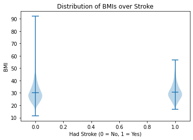

```python
#Creating an array to store 2 numpy arrays - one for the BMIs of patients who
#had a stroke and one for the patients who did not.
bmi_list = []

#Setting the axis labels and title.
plt.title('Distribution of BMIs over Stroke')
plt.xlabel("Had Stroke (0 = No, 1 = Yes)")
plt.ylabel("BMI")

#Create 2 temporary tables - one for patients where stroke = 0 and one for patients where stroke = 1
for val in stroke_val_list:
  temp = data[data['stroke'] == val]
  #Convert the BMI column in this dataframe to a numpy array, and append it to the final list.
  bmis = temp['bmi'].to_numpy()
  bmi_list.append(bmis)

#Creating the violinplot, using the example shown in the instructions.
plt.violinplot(bmi_list, stroke_val_list, widths=.1, showmeans=True)
```

Both distributions have a mean of 30, but the skew of the distribution for patients who did not have a stroke is much greater than the distribution for those that did. Therefore, it is unclear whether BMI could have an effect on stroke.

```
{'bodies': [<matplotlib.collections.PolyCollection at 0x7f2305b37750>,
 'cbars': <matplotlib.collections.LineCollection at 0x7f2305b20a90>,
 'cmaxes': <matplotlib.collections.LineCollection at 0x7f2305b20650>,
 'cmeans': <matplotlib.collections.LineCollection at 0x7f2305b46790>,
 'cmins': <matplotlib.collections.LineCollection at 0x7f2305b377d0>}
```

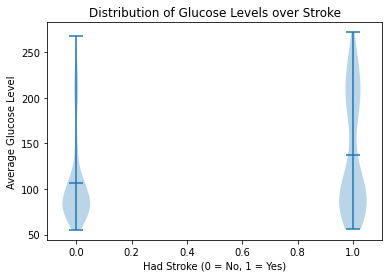

```python
#Creating an array to store 2 numpy arrays - one for the glucose levels of patients who
#had a stroke and one for the patients who did not.
glucose_list = []

#Setting the axis labels and title.
plt.title('Distribution of Glucose Levels over Stroke')
plt.xlabel("Had Stroke (0 = No, 1 = Yes)")
plt.ylabel("Average Glucose Level")

#Create 2 temporary tables - one for patients where stroke = 0 and one for patients where stroke = 1
for val in stroke_val_list:
  temp = data[data['stroke'] == val]
  #Convert the glucose level column in this dataframe to a numpy array, and append it to the final list.
  glucose = temp['avg_glucose_level'].to_numpy()
  glucose_list.append(glucose)

#Creating the violinplot, using the example shown in the instructions.
plt.violinplot(glucose_list, stroke_val_list, widths=.1, showmeans=True)
```

The mean of the distribution of glucose levels where the patient had a stroke is higher than the mean of the distribution where the patient did not have a stroke. In addition, although both distributions are right-skewed, the distribution where stroke = 0 had a much larger skew than the distribution where stroke = 1.

Therefore, it is very likely that the glucose level impacts with whether the person had a stroke or not.

# Exploratory Data Analysis - Qualitative Variables

Next, we analyze the relationship of our cateogorical variables with the stroke variable. We use the seaborn library to create countplots, which show the frequency of the target variable (in this case, stroke as 0 or 1), separated by the categorical variable.

The data is split into two different tables - one containing patients who had a stroke, and one who didn't. Normally, you can get include both countplots on a single graph, but they were included in different plots so that it is much easier to visually recognize the changes in relative frequency across the two stroke values.

Click the link to explore how to use the seaborn library in your project: https://seaborn.pydata.org/generated/seaborn.countplot.html

The way to determine whether a categorical variable signficantly affects the target variable (stroke) is to observe if, and how, the count distribution changes when stroke = 0 verses stroke = 1. If there is a large difference, it indicates that the categorical variable has a strong impact on whether the person had a stroke or not.

Note that the title is for each pair of graphs, so there is one title every 2 graphs (one for each stroke value).

The countplot is very similar to a frequency chart - the details of which you can find here: https://www.statisticshowto.com/how-to-make-a-frequency-chart-and-determine-frequency/

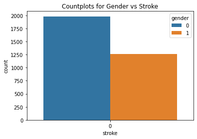

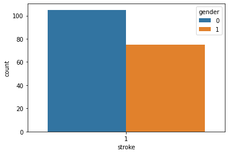

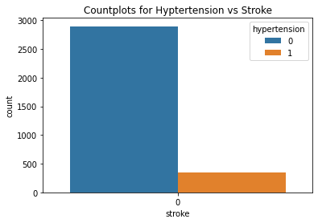

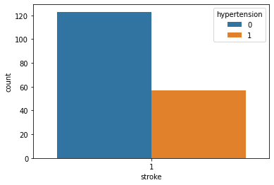

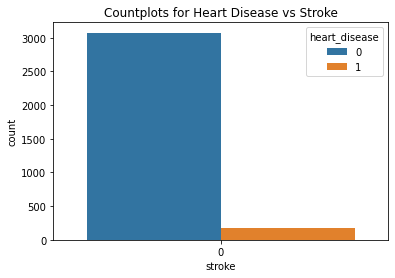

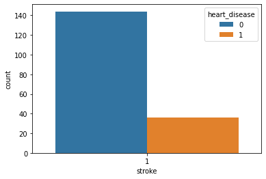

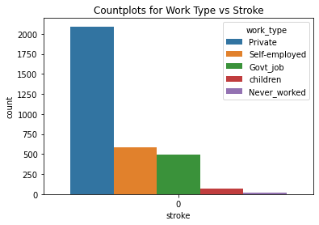

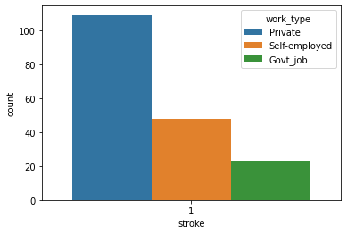

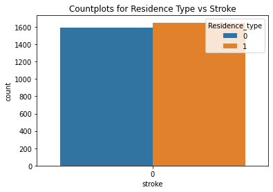

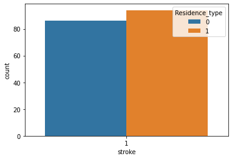

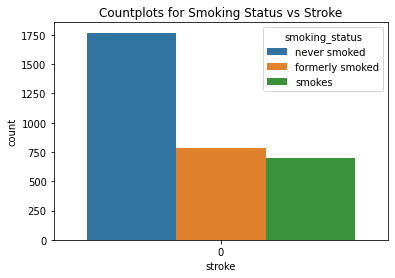

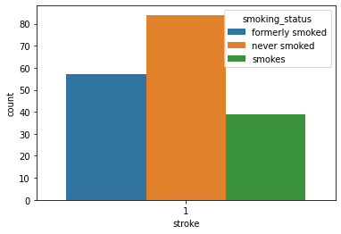

```python
import seaborn as sns

#Splitting the original table into two tables - one for each value of stroke (0 or 1).
nostroke = data[data['stroke'] == 0]
yesstroke = data[data['stroke'] == 1]

#Writing a function that takes in a feature, and makes the appropriate countplots.
def print_count_plot(feature):
  sns.countplot(nostroke['stroke'], hue = nostroke[feature])
  plt.show()
  sns.countplot(yesstroke['stroke'], hue = yesstroke[feature])
  plt.show()

#First we set the title for each of the countplots. The x-axis and y-axis labels
#will already be set in the plots, conting the value of stroke, and the counts.
plt.title('Countplots for Gender vs Stroke')
print_count_plot('gender')
plt.title('Countplots for Hyptertension vs Stroke')
print_count_plot('hypertension')
plt.title('Countplots for Heart Disease vs Stroke')
print_count_plot('heart_disease')
plt.title('Countplots for Work Type vs Stroke')
print_count_plot('work_type')
plt.title('Countplots for Residence Type vs Stroke')
print_count_plot('Residence_type')
plt.title('Countplots for Smoking Status vs Stroke')
print_count_plot('smoking_status')
```

From the analysis above, we see that the countplots that the variables hypertension, heart disease, and smoking_status had a significant impact on whether the person had a stroke or not. For countplot where the hue is hypertension, there was a much higher relative frequency of patients with hpertension in the countplot of patients who had a stroke verses those who didn't. The exact same analysis can be made for the countplots analyzing heart disease - the group of patients who experienced a stroke had a much higher amount of people with heart disease.

For the binary variable of residency type, the distributions look very similar for the countplots where stroke = 0 and stroke = 1, so it is very unlikely that this variable had an effect. Thus, it is reasonable to exclude this feature from the classification analysis in the future.

In summary, having heart disease, hypertension, and a history of smoking are more likely to have experienced a stroke before.

```python
#Dropping Residence type, since we discovered that it does not have a significant effect on whether a person has a stroke.
data = data.drop(columns = ['Residence_type'])
```

# Machine Learning

Here, we are building and testing a classification model. The goal is to use features, which include all the categorical and numerical variables that we have analyzed in the explanatory data analysis, to predict the target, which is whether the patient had a stroke or not.

First, one-hot encoding is used to convert work_type and smoking_status, the only 2 multi-level categorical variables, into dummy variables.

here is the guide to creating dummy variables using the Pandas library: https://pandas.pydata.org/docs/reference/api/pandas.get_dummies.html

```python
dummies = pd.get_dummies(data[['work_type','smoking_status']])
dummies
data=data.merge(dummies, left_index = True, right_index = True, how = 'left')
data = data.drop(columns=['work_type', 'smoking_status'])
data
```

|  | gender | age | hypertension | heart_disease | avg_glucose_level | bmi | stroke | work_type_Govt_job | work_type_Never_worked | work_type_Private | work_type_Self-employed | work_type_children | smoking_status_formerly smoked | smoking_status_never smoked | smoking_status_smokes |
| --- | --- | --- | --- | --- | --- | --- | --- | --- | --- | --- | --- | --- | --- | --- | --- |
| 0 | 1 | 67.0 | 0 | 1 | 228.69 | 36.6 | 1 | 0 | 0 | 1 | 0 | 0 | 1 | 0 | 0 |
| 2 | 1 | 80.0 | 0 | 1 | 105.92 | 32.5 | 1 | 0 | 0 | 1 | 0 | 0 | 0 | 1 | 0 |
| 3 | 0 | 49.0 | 0 | 0 | 171.23 | 34.4 | 1 | 0 | 0 | 1 | 0 | 0 | 0 | 0 | 1 |
| 4 | 0 | 79.0 | 1 | 0 | 174.12 | 24.0 | 1 | 0 | 0 | 0 | 1 | 0 | 0 | 1 | 0 |
| 5 | 1 | 81.0 | 0 | 0 | 186.21 | 29.0 | 1 | 0 | 0 | 1 | 0 | 0 | 1 | 0 | 0 |
| ... | ... | ... | ... | ... | ... | ... | ... | ... | ... | ... | ... | ... | ... | ... | ... |
| 5100 | 1 | 82.0 | 1 | 0 | 71.97 | 28.3 | 0 | 0 | 0 | 0 | 1 | 0 | 0 | 1 | 0 |
| 5102 | 0 | 57.0 | 0 | 0 | 77.93 | 21.7 | 0 | 0 | 0 | 1 | 0 | 0 | 0 | 1 | 0 |
| 5106 | 0 | 81.0 | 0 | 0 | 125.20 | 40.0 | 0 | 0 | 0 | 0 | 1 | 0 | 0 | 1 | 0 |
| 5107 | 0 | 35.0 | 0 | 0 | 82.99 | 30.6 | 0 | 0 | 0 | 0 | 1 | 0 | 0 | 1 | 0 |
| 5108 | 1 | 51.0 | 0 | 0 | 166.29 | 25.6 | 0 | 0 | 0 | 1 | 0 | 0 | 1 | 0 | 0 |

3426 rows × 15 columns

Then, we fit a classification model, which will be used to predict whether an arbitrary patient had a stroke or not.

For our classification problem, we have various models at our disposal: Logistic Regression, k-nearest neighbors, linear/polynomial support vector machines, and decision trees. The most viable options in this situation are Logistic Regression and decision trees.

There are two main reasons why using decision trees is the most appropriate course of action:

1. The data contains many categorical variables, which is why we used One-Hot encoding to create the dummy variables for analysis. However, this results in dimension problems that may not be properly handled by logistic regression, so decision trees are the better option.
2. We saw through violinplots that there is heavy skew across our numerical variables in our data, and logistic regression does not handle skew well. Therefore, decision trees are the best option in this regard.

The webpage below gives an overview of the pros and cons of using each model: https://dzone.com/articles/logistic-regression-vs-decision-tree#:~:text=Decision%20Trees%20are%20non%2Dlinear,data%20to%20be%20linearly%20separable.&text=When%20you%20are%20sure%20that,will%20take%20care%20of%20both.

You can find more information about the topics discussed above: https://scikit-learn.org/stable/modules/tree.html https://scikit-learn.org/stable/modules/generated/sklearn.linear_model.LogisticRegression.html

```python
#Importing various useful libraries for building, training, and testing the machine learning model.
from sklearn.model_selection import train_test_split
from sklearn.tree import DecisionTreeClassifier
from sklearn.model_selection import KFold

#Initializing the type of model.
model = DecisionTreeClassifier()

#The X_data contains all the columns containing the features, excluding 'stroke', which is the target variable.
X_data = np.asarray(data.drop(columns=['stroke']))
#The y_data contains one column, 'stroke', whose value we wish to predict through the model.
y_data = np.asarray(data['stroke'])
```

# Classification Model Training and Testing

In this grand finale, we train our model to predict whether a person had a stroke, based on various features like age, glucose level, etc.

In each split, we fit the model using the training x and y sets, predict the output, and then compare the predictions with the actual values (stored in y_test). This will enable us to know how many predictions were correct.

```python
#Initializtion of the training/test sets used for the 10-fold cross validation.
x_train = []
y_train = []
x_test = []
y_test = []


#Splitting the data into each array using the indicies returned by
#'train' and 'test', generated by the 10-fold cross validation.

#Total amount of observations in the test set, printed to display.
print('Number of Observations in the test set: ' + str(343) + '\n')

#Used for tracking the fold #:
f = 1

#Running the 10-fold cross validation procedure, 10% of the data is for the test for each fold.
for train, test in KFold(n_splits=10, shuffle=True).split(X_data):
  X_train = X_data[train]
  y_train = y_data[train]
  X_test = X_data[test]
  y_test = y_data[test]

  #Fitting the model according to the x and y values of the training set, and
  #then obtaining the prediction value.
  model.fit(X_train, y_train)
  pred = model.predict(X_test)
  print('Fold #' + str(f))
  f += 1
  correct = 0
  for i in range(len(pred)):
    #Increment correct for each correct prediction
    if (pred[i] == y_test[i]):
        correct += 1
  print("Number correct: " + str(correct) + '\n')
```

```
Number of Observations in the test set: 343

Fold #1
Number correct: 319

Fold #2
Number correct: 302

Fold #3
Number correct: 314

Fold #4
Number correct: 309

Fold #5
Number correct: 308

Fold #6
Number correct: 310

Fold #7
Number correct: 306

Fold #8
Number correct: 308

Fold #9
Number correct: 309

Fold #10
Number correct: 305
```

We started by importing the appropriate libraries that are required to complete implementing the machine learning classification model. These are from Scikit-learn machine learning library, which contains many tools for various regression, clustering and classification algorithms.

Here are the guides to each of the modules imported above:

train_test_split: https://scikit-learn.org/stable/modules/generated/sklearn.model_selection.train_test_split.html

DecisionTreeClassifier https://scikit-learn.org/stable/modules/generated/sklearn.tree.DecisionTreeClassifier.html

Kfold: https://scikit-learn.org/stable/modules/generated/sklearn.model_selection.KFold.html#:~:text=Provides%20train%2Ftest%20indices%20to,folds%20form%20the%20training%20set.

# Conclusion

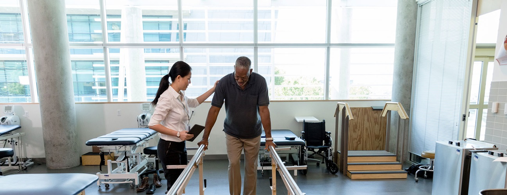

n The data has clearly shown how several factors in the dataset affect whether someone is prone to experiencing a stroke. It is important that various attributes in this dataset be analyzed by doctors and professionals to more accurately evaluate the risk a patient has to getting a stroke, so they can diagnose problems and implement solutions quickly in the future.

Through this tutorial, I hope that you have learned how to prepare data for analysis, represent the data through various different transformations, explore data through various types of displays, and interpret the results in a meaningful way. You also have learned how to train a classifier model to predict a target variable based on features, and how to assess the accuracy of your predictions.

By using data science to draw meaningful and insightful inferences related to medical data, solutions can be implemented to prevent medical tragedies like storke, and save countless lives.